# STAT240 DIS343 Group 3 Project Draft

2026-04-21

## Group Members

- Devika
- Quenby
- Roshan

## Introduction

The availability of prenatal technology and care is crucial for the comfort and safety of expectant mothers. However, the gap in access and funding across different countries is continually widening. Before the deficit in some countries can be remedied, the actual needs and effects must be identified and studied. This inadequacy leads to the question, “How does lack of antenatal care impact maternal mortality and complication rates?” Many women around the world experience life threatening complications during pregnancy, and while giving birth, and after birth. These complications and causes of death include deaths from induced abortions without proper medical care, ectopic pregnancy, postpartum depression, hemorrhage, hypertension, sepsis, unsafe birthing conditions, obstructed labor, or other indirect causes (such as HIV/AIDS). The data represented may also be limited by the fact that much of this data’s collection happens at hospitals and other medical facilities. Therefore, pregnancy outcomes that do not occur at medical facilities and are not otherwise reported will not be included in general data. This limitation could artificially deflate certain countries’ reported Maternal Mortality Rates. The complications associated with pregnancy and giving birth are often preventable. These preventative measures require funding and education for medical professionals and mothers which leads us to believe that people in countries with less access to prenatal care have higher mortality and complication rates. Maternal Mortality is a public health issue that we believe increased access to antenatal care/resources would help to solve.

## Background

### Data Sources

- Raw Data: The raw data we are using for this study is directly from the World Health Organization website. [WHO Maternal Mortality](https://www.who.int/data/gho/data/themes/topics/sdg-target-3-1-maternal-mortality) contains data on the maternal mortality by country. WHO Maternal Mortality Ratio contains data on the ratio of maternal mortality based on the ability to access pre-natal care.

### Variables

- Maternal Mortality: Maternal Mortality Ratio (deaths per 100,000 live births) for the year 2021 or the most recent checkpoint. This reflects the risk of maternal death in a single pregnancy, not cumulative lifetime risk.
- Antenatal Coverage: Women who received antenatal care four or more times during pregnancy (%). A measure of access to and utilization of prenatal healthcare.
- Needs Met: Proportion of women of reproductive age whose demand for family planning is satisfied by modern contraceptive methods (%). A measure of access to reproductive education and contraception.

### Data Cleaning and Processing

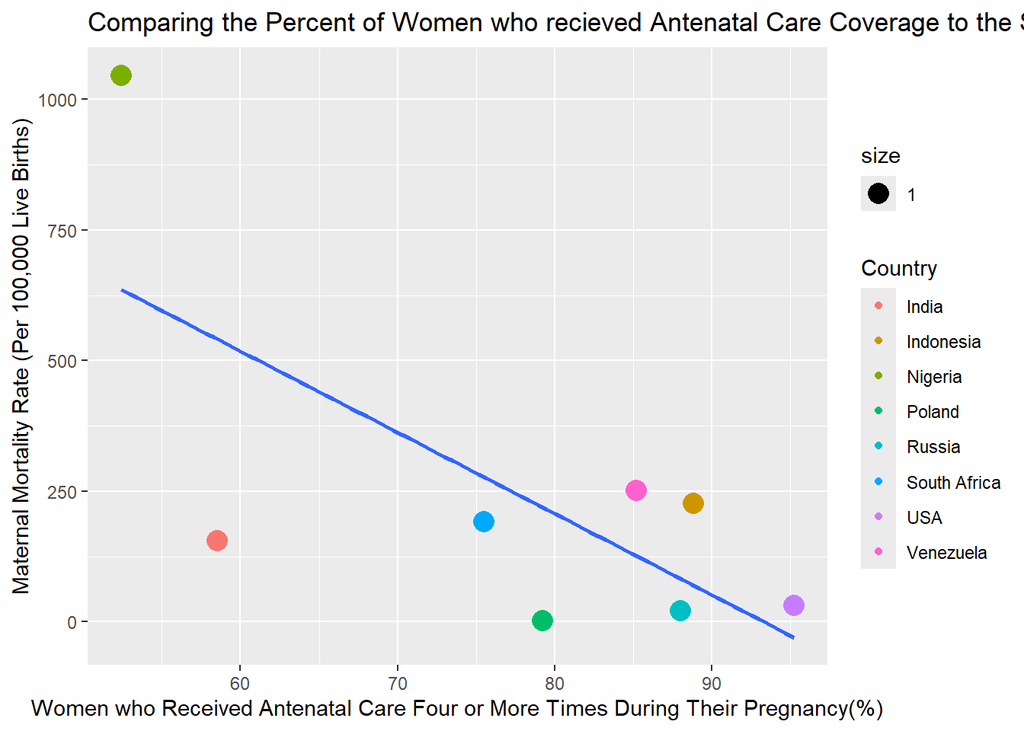

```
##                Estimate Std. Error   t value     Pr(>|t|)
## (Intercept) 85.29120094 5.22693755 16.317624 3.372493e-06
## MatMort     -0.03094859 0.01311814 -2.359222 5.634396e-02
```

### Hypotheses

We believe that better access to antenatal care decreases the maternal mortality rate by country.